# Figure 1: SI Ratio & Time in IZ Zone

### Libraries & Config

```r
library(here)
library(glue)
library(dplyr)
library(tidyr)
library(knitr)
library(pander)
library(ggplot2)
library(ggpubr)
library(pwr)
library(effectsize)
library(grid)
library(cowplot)
library(emmeans)
```

```r
source(here('styles.R'))
data_path <- here('data')
SIT_diff <- readRDS(glue('{data_path}/SIT_diff_primary.rds'))
SIT_raw <- readRDS(glue('{data_path}/SIT_raw_primary.rds'))
```

### SI Ratio effects are larger in males than in females (Fig. 1b)

Following exposure to CSW/DS, SI ratio is reduced in males and females compared to non-stressed controls. This effect is driven by changes in stressed animals, as male and female control mice do not differ significantly from each other.

```r
# PLOT ----

point <- ggplot(SIT_diff, aes(Condition, IZ_time, color = full_cond, fill = full_cond)) +
              geom_hline(yintercept = 1) +
              geom_jitter(width = 0.2, alpha = 0.2, height = 0, size = 0.5) +
              stat_summary(fun = 'mean', geom = 'point', size = 0.5) +
              stat_summary(fun.data = 'mean_se', geom = 'errorbar',
                           linewidth = 1, width = 0.4) +
              scale_y_continuous(name = 'SI Ratio', expand = c(0,0,0.3,0)) +
              facet_wrap(Sex ~ ., nrow = 2) +
              scale_color_manual(values = col_full) +
              scale_fill_manual(values = col_full) +
              plot_theme +
              theme(legend.position = 'None',
                    axis.title.x = element_blank(),
                    plot.margin = unit(c(0,0,0,0), 'cm'))

hist <- ggplot(SIT_diff, aes(y=IZ_time, color = full_cond, fill = full_cond)) +
              geom_hline(yintercept = 1) +
              geom_density(alpha = 0.4) +
              scale_x_continuous(expand = c(0,0), limits = c(0,1.2),
                                 breaks = c(0,0.5,1),  name = c('Density')) +
              scale_y_continuous(name = 'SI Ratio', expand = c(0,0,0.3,0)) +
              scale_color_manual(values = col_full) +
              scale_fill_manual(values = col_full) +
              plot_theme +
              facet_wrap(Sex ~ ., nrow = 2) +
              theme(legend.position = 'None',
                    axis.line = element_blank(),
                    axis.ticks = element_blank(),
                    axis.title = element_blank(),
                    axis.text = element_blank(),
                    strip.text = element_blank(),
                    plot.margin = unit(c(0,0,0,0), 'cm'))

# STATS ----

# ANOVA
aov_SIratio <- aov(IZ_time ~ Condition * Sex + cohort, SIT_diff)
sum_aov_SIratio <- summary(aov_SIratio)

sidak_cond_sex <- pairs(emmeans(aov_SIratio, ~ Condition | Sex), adjust = 'sidak')
sidak_sex_cond <- pairs(emmeans(aov_SIratio, ~ Sex | Condition), adjust = 'sidak')
```

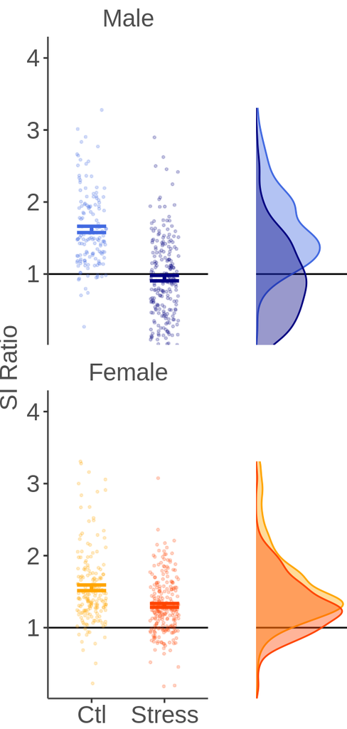

Analysis of Variance Model

|  | Df | Sum Sq | Mean Sq | F value | Pr(>F) |
| --- | --- | --- | --- | --- | --- |
| **Condition** | 1 | 37.52 | 37.52 | 165.1 | 2.976e-34 |
| **Sex** | 1 | 6.709 | 6.709 | 29.53 | 7.477e-08 |
| **cohort** | 19 | 18.6 | 0.979 | 4.309 | 3.327e-09 |
| **Condition:Sex** | 1 | 8.128 | 8.128 | 35.78 | 3.446e-09 |
| **Residuals** | 738 | 167.7 | 0.2272 | NA | NA |

Sidak Post-Hoc Planned Contrasts

| Sex | Condition | contrast | estimate | SE | df | t.ratio | p.value |
| --- | --- | --- | --- | --- | --- | --- | --- |
| Male | . | Ctl - Stress | 0.69 | 0.05 | 738 | 13.23 | 0 |
| Female | . | Ctl - Stress | 0.26 | 0.05 | 738 | 5.46 | 0 |
| . | Ctl | Male - Female | 0.01 | 0.06 | 738 | 0.13 | 1 |
| . | Stress | Male - Female | -0.42 | 0.05 | 738 | -8.83 | 0 |

We then calculated effect sizes for males and females. For this, we performed a t-test for male and female data separately as a basis to calculate hedge’s *g*. This value was then used to calculate the sample size required **per group** for an adequately powered experiment (*power* = 0.8), as well as to calculate the power currently achieved when using sample sizes ranging from 8-15 animals per group.

```r
# ES
m_data <- SIT_diff[SIT_diff$Sex == 'Male',]
t_SIratio_m <- t.test(IZ_time ~ Condition, data = m_data) # t-test
g_t_SIratio_m <- hedges_g(IZ_time ~ Condition, data = m_data)$Hedges_g # hedge's g
n_t_m <- pwr.t.test(d = g_t_SIratio_m, power = 0.8,
                    sig.level = 0.05, type = "two.sample") # sample size for power = 0.8
pwr_t_low_m <- pwr.t.test(d = g_t_SIratio_m, n = 8,
                          sig.level = 0.05, type = "two.sample") # power with n = 8
pwr_t_high_m <- pwr.t.test(d = g_t_SIratio_m, n = 15,
                           sig.level = 0.05, type = "two.sample") # power with n = 15

f_data <- SIT_diff[SIT_diff$Sex == 'Female',]
t_SIratio_f <- t.test(IZ_time ~ Condition, data = f_data) # t-test
g_t_SIratio_f <- hedges_g(IZ_time ~ Condition, data = f_data)$Hedges_g # hedge's g
n_t_f <- pwr.t.test(d = g_t_SIratio_f, power = 0.8,
                    sig.level = 0.05, type = "two.sample") # sample size for power = 0.8
pwr_t_low_f <- pwr.t.test(d = g_t_SIratio_f, n = 8,
                          sig.level = 0.05, type = "two.sample") # power with n = 8
pwr_t_high_f <- pwr.t.test(d = g_t_SIratio_f, n = 15,
                           sig.level = 0.05, type = "two.sample") # power with n = 15

es <- tibble("Sex" = c('Male', 'Female'),
             "t Value" = c(round(t_SIratio_m$statistic, 2), round(t_SIratio_f$statistic, 2)),
             "df" = c(round(t_SIratio_m$parameter, 2), round(t_SIratio_f$parameter, 2)),
             "Hedge's g" = c(round(g_t_SIratio_m, 2), round(g_t_SIratio_f, 2)),
             "n (pwr = 0.8)" = c(ceiling(n_t_m$n), ceiling(n_t_f$n)),
             "pwr (n = 8)" = c(round(pwr_t_low_m$power, 2), round(pwr_t_low_f$power, 2)),
             "pwr (n = 15)" = c(round(pwr_t_high_m$power, 2), round(pwr_t_high_f$power, 2)))

# Variance test
var_ctl <- var.test(IZ_time ~ Sex, SIT_diff[SIT_diff$Condition == 'Ctl',],
                    alternative = "two.sided")
var_stress <- var.test(IZ_time ~ Sex, SIT_diff[SIT_diff$Condition == 'Stress',],
                       alternative = "two.sided")
var_test <- tibble("Group" = c('Control', 'Stress'),
                   "F Value" = c(var_ctl$statistic, var_stress$statistic),
                   "df" = c(paste0(var_ctl$parameter[1], ',', var_ctl$parameter[2]),
                            paste0(var_stress$parameter[1], ',', var_stress$parameter[2])),
                   "p Value" = c(var_ctl$p.value, var_stress$p.value))

kable(es)
```

| Sex | t Value | df | Hedge’s g | n (pwr = 0.8) | pwr (n = 8) | pwr (n = 15) |
| --- | --- | --- | --- | --- | --- | --- |
| Male | 11.69 | 313.49 | 1.25 | 12 | 0.64 | 0.91 |
| Female | 5.19 | 311.11 | 0.54 | 55 | 0.17 | 0.30 |

```r
kable(var_test)
```

| Group | F Value | df | p Value |
| --- | --- | --- | --- |
| Control | 1.005789 | 140,173 | 0.9668912 |
| Stress | 2.013947 | 215,229 | 0.0000002 |

### Raw data confirm differential effects in defeated males and witness females (Fig. 1c)

Finally, we tested if female witnesses showed evidence of stress effects in the raw time in the interaction zone, that may be masked when computing the SI ratio. Defeated males show reduced time in their interaction zone only during the Target trial. In contrast, witness females show a modest increase in time in the interaction zone in the No Target trial, and a modest decrease during the Target trial compared to controls.

```r
# PLOT ----
point_raw <- ggplot(SIT_raw, aes(Condition, IZ_time, color = full_cond, fill = full_cond)) +
                        geom_jitter(width = 0.2, alpha = 0.2, height = 0, size = 0.5) +
                        stat_summary(fun = 'mean', geom = 'point', size = 0.5) +
                        stat_summary(fun.data = 'mean_se', geom = 'errorbar',
                                    linewidth = 1, width = 0.4) +
                        scale_y_continuous(name = 'Time in Interaction Zone (s)', expand = c(0,0,0.3,0)) +
                        facet_grid(Sex ~ Trial_type) +
                        scale_color_manual(values = col_full) +
                        scale_fill_manual(values = col_full) +
                        plot_theme +
                        theme(legend.position = 'None',
                                axis.title.x = element_blank(),
                                panel.spacing.y = unit(2, "lines"))

# STATS ----

# ANOVAs per sex
m_data <- SIT_raw[SIT_raw$Sex == 'Male',]
m_aov <- aov(IZ_time ~ Condition * Trial_type + cohort + Error(id_full), m_data)
f_data <- SIT_raw[SIT_raw$Sex == 'Female',]
f_aov <- aov(IZ_time ~ Condition * Trial_type + cohort + Error(id_full), f_data)

# Sidak
sidak_cond_tt_m <- pairs(emmeans(m_aov, ~ Condition | Trial_type), adjust = 'sidak')
sidak_tt_cond_m <- pairs(emmeans(m_aov, ~ Trial_type | Condition), adjust = 'sidak')
sidak_cond_tt_f <- pairs(emmeans(f_aov, ~ Condition | Trial_type), adjust = 'sidak')
sidak_tt_cond_f <- pairs(emmeans(f_aov, ~ Trial_type | Condition), adjust = 'sidak')
```

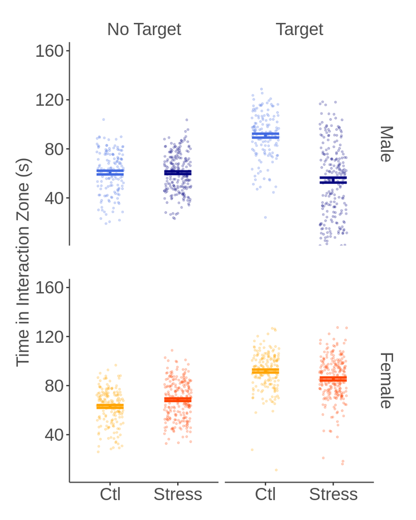

rmANOVA in Males

|  | Df | Sum Sq | Mean Sq | F value | Pr(>F) |
| --- | --- | --- | --- | --- | --- |
| **Condition** | 1 | 56367 | 56367 | 117.8 | 9.75e-24 |
| **cohort** | 17 | 45166 | 2657 | 5.55 | 4.868e-11 |
| **Residuals** | 338 | 161796 | 478.7 | NA | NA |
| **Trial_type** | 1 | 12077 | 12077 | 32.65 | 2.339e-08 |
| **Condition:Trial_type** | 1 | 55816 | 55816 | 150.9 | 3.815e-29 |
| **Residuals** | 355 | 131317 | 369.9 | NA | NA |

Sidak Post-Hoc Planned Contrasts in Males

| Trial_type | Condition | contrast | estimate | SE | df | t.ratio | p.value |
| --- | --- | --- | --- | --- | --- | --- | --- |
| No Target | . | Ctl - Stress | -0.15069 | 2.24116 | 675.4225 | -0.06724 | 1.00000 |
| Target | . | Ctl - Stress | 36.02302 | 2.24116 | 675.4225 | 16.07338 | 0.00000 |
| . | Ctl | No Target - Target | -30.11220 | 2.29061 | 355.0000 | -13.14593 | 0.00000 |
| . | Stress | No Target - Target | 6.06151 | 1.85069 | 355.0000 | 3.27527 | 0.00464 |

rmANOVA in Females

|  | Df | Sum Sq | Mean Sq | F value | Pr(>F) |
| --- | --- | --- | --- | --- | --- |
| **Condition** | 1 | 45.86 | 45.86 | 0.1994 | 0.6554 |
| **cohort** | 17 | 31905 | 1877 | 8.162 | 1.115e-17 |
| **Residuals** | 385 | 88523 | 229.9 | NA | NA |
| **Trial_type** | 1 | 98272 | 98272 | 431 | 1.369e-65 |
| **Condition:Trial_type** | 1 | 7076 | 7076 | 31.04 | 4.644e-08 |
| **Residuals** | 402 | 91650 | 228 | NA | NA |

Sidak Post-Hoc Planned Contrasts in Females

| Trial_type | Condition | contrast | estimate | SE | df | t.ratio | p.value |
| --- | --- | --- | --- | --- | --- | --- | --- |
| No Target | . | Ctl - Stress | -6.20800 | 1.52559 | 786.157 | -4.06925 | 0.00021 |
| Target | . | Ctl - Stress | 5.74450 | 1.52559 | 786.157 | 3.76544 | 0.00071 |
| . | Ctl | No Target - Target | -28.86129 | 1.61880 | 402.000 | -17.82883 | 0.00000 |
| . | Stress | No Target - Target | -16.90879 | 1.40800 | 402.000 | -12.00906 | 0.00000 |